# Customer Success Analytics

Jennifer Amador-Gonzalez

2025-01-03

## Load and Explore Data

```r
#installying and loading necessary library
library(tidyverse)
#leading dataset from files
file_path <- "/Users/jenniferamador/Downloads/telco.csv"
telco_data <-  read_csv(file_path)
#exploring dataset
head(telco_data) #first few rows
```

```
## # A tibble: 6 × 50
##   `Customer ID` Gender   Age `Under 30` `Senior Citizen` Married Dependents
##   <chr>         <chr>  <dbl> <chr>      <chr>            <chr>   <chr>
## 1 8779-QRDMV    Male      78 No         Yes              No      No
## 2 7495-OOKFY    Female    74 No         Yes              Yes     Yes
## 3 1658-BYGOY    Male      71 No         Yes              No      Yes
## 4 4598-XLKNJ    Female    78 No         Yes              Yes     Yes
## 5 4846-WHAFZ    Female    80 No         Yes              Yes     Yes
## 6 4412-YLTKF    Female    72 No         Yes              No      Yes
## # ℹ 43 more variables: `Number of Dependents` <dbl>, Country <chr>,
## #   State <chr>, City <chr>, `Zip Code` <dbl>, Latitude <dbl>, Longitude <dbl>,
## #   Population <dbl>, Quarter <chr>, `Referred a Friend` <chr>,
## #   `Number of Referrals` <dbl>, `Tenure in Months` <dbl>, Offer <chr>,
## #   `Phone Service` <chr>, `Avg Monthly Long Distance Charges` <dbl>,
## #   `Multiple Lines` <chr>, `Internet Service` <chr>, `Internet Type` <chr>,
## #   `Avg Monthly GB Download` <dbl>, `Online Security` <chr>, …
```

```r
glimpse(telco_data) #structure and data types
```

```
## Rows: 7,043
## Columns: 50
## $ `Customer ID`                       <chr> "8779-QRDMV", "7495-OOKFY", "1658-…
## $ Gender                              <chr> "Male", "Female", "Male", "Female"…
## $ Age                                 <dbl> 78, 74, 71, 78, 80, 72, 76, 66, 70…
## $ `Under 30`                          <chr> "No", "No", "No", "No", "No", "No"…
## $ `Senior Citizen`                    <chr> "Yes", "Yes", "Yes", "Yes", "Yes",…
## $ Married                             <chr> "No", "Yes", "No", "Yes", "Yes", "…
## $ Dependents                          <chr> "No", "Yes", "Yes", "Yes", "Yes", …
## $ `Number of Dependents`              <dbl> 0, 1, 3, 1, 1, 1, 2, 0, 2, 2, 1, 0…
## $ Country                             <chr> "United States", "United States", …
## $ State                               <chr> "California", "California", "Calif…
## $ City                                <chr> "Los Angeles", "Los Angeles", "Los…
## $ `Zip Code`                          <dbl> 90022, 90063, 90065, 90303, 90602,…
## $ Latitude                            <dbl> 34.02381, 34.04427, 34.10883, 33.9…
```

[output cut: 37 more lines]

```r
summary(telco_data) # summary statistics
```

```
##  Customer ID           Gender               Age          Under 30
##  Length:7043        Length:7043        Min.   :19.00   Length:7043
##  Class :character   Class :character   1st Qu.:32.00   Class :character
##  Mode  :character   Mode  :character   Median :46.00   Mode  :character
##                                        Mean   :46.51
##                                        3rd Qu.:60.00
##                                        Max.   :80.00
##  Senior Citizen       Married           Dependents        Number of Dependents
##  Length:7043        Length:7043        Length:7043        Min.   :0.0000
##  Class :character   Class :character   Class :character   1st Qu.:0.0000
##  Mode  :character   Mode  :character   Mode  :character   Median :0.0000
##                                                           Mean   :0.4687
##                                                           3rd Qu.:0.0000
##                                                           Max.   :9.0000
##    Country             State               City              Zip Code
##  Length:7043        Length:7043        Length:7043        Min.   :90001
##  Class :character   Class :character   Class :character   1st Qu.:92101
##  Mode  :character   Mode  :character   Mode  :character   Median :93518
##                                                           Mean   :93486
##                                                           3rd Qu.:95329
##                                                           Max.   :96150
##     Latitude       Longitude        Population       Quarter
##  Min.   :32.56   Min.   :-124.3   Min.   :    11   Length:7043
##  1st Qu.:33.99   1st Qu.:-121.8   1st Qu.:  2344   Class :character
##  Median :36.21   Median :-119.6   Median : 17554   Mode  :character
##  Mean   :36.20   Mean   :-119.8   Mean   : 22140
##  3rd Qu.:38.16   3rd Qu.:-118.0   3rd Qu.: 36125
##  Max.   :41.96   Max.   :-114.2   Max.   :105285
##  Referred a Friend  Number of Referrals Tenure in Months    Offer
##  Length:7043        Min.   : 0.000      Min.   : 1.00    Length:7043
##  Class :character   1st Qu.: 0.000      1st Qu.: 9.00    Class :character
##  Mode  :character   Median : 0.000      Median :29.00    Mode  :character
##                     Mean   : 1.952      Mean   :32.39
##                     3rd Qu.: 3.000      3rd Qu.:55.00
##                     Max.   :11.000      Max.   :72.00
##  Phone Service      Avg Monthly Long Distance Charges Multiple Lines
##  Length:7043        Min.   : 0.00                     Length:7043
##  Class :character   1st Qu.: 9.21                     Class :character
##  Mode  :character   Median :22.89                     Mode  :character
##                     Mean   :22.96
```

[output cut: 43 more lines]

```
##  Max.   :3564.72             Max.   :11979.34   Max.   :5.000
##  Customer Status    Churn Label         Churn Score         CLTV
##  Length:7043        Length:7043        Min.   : 5.00   Min.   :2003
##  Class :character   Class :character   1st Qu.:40.00   1st Qu.:3469
##  Mode  :character   Mode  :character   Median :61.00   Median :4527
##                                        Mean   :58.51   Mean   :4400
##                                        3rd Qu.:75.50   3rd Qu.:5380
##                                        Max.   :96.00   Max.   :6500
##  Churn Category     Churn Reason
##  Length:7043        Length:7043
##  Class :character   Class :character
##  Mode  :character   Mode  :character
##
##
##
```

```r
#Goal
#check for potential missing values
#understand column data types (categorical vs. numerical)
#identify. the targeet variable (churn) and key predictors (ex: tenure, monthly charges)
```

## Clean Data

```r
#handle missing values
telco_clean <- telco_data %>% mutate(`Total Charges`=as.numeric(`Total Charges`)) #ensure to convert to numeric
telco_clean <- telco_data %>% drop_na() #drop any rows with missing values

#convert categorical variables to numerical
telco_clean <- telco_data %>% mutate(`Churn` = ifelse(`Churn Label`== "Yes", 1, 0)) #target variable

#Goals
#Handle missing values
#convert categorical variables to numerical for potential modeling
```

##Exploratory Data Analysis (EDA)

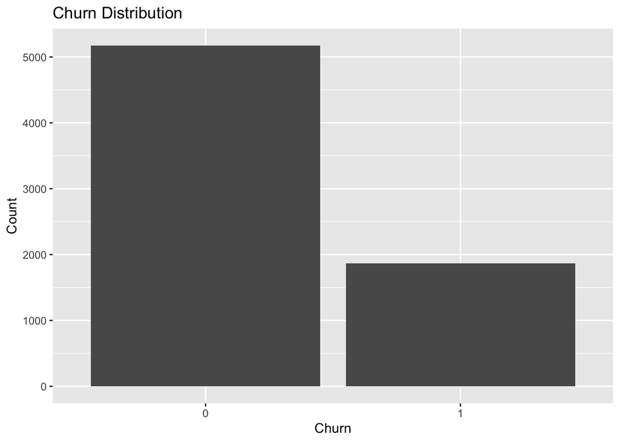

```r
#load necessary library
library(ggplot2)

#churn distribution
ggplot(telco_clean,aes (x = factor(Churn))) + geom_bar() + labs(title = "Churn Distribution", x = "Churn",  y= "Count")
```

Observations: The majority of customers (non-churners) do not churn (label 0). Churners (label 1) make up a smaller proportion of the dataset. Insight: This indicates class imbalance, which is common in churn datasets and should be addressed in modeling (e.g., using balanced sampling or weighted metrics).

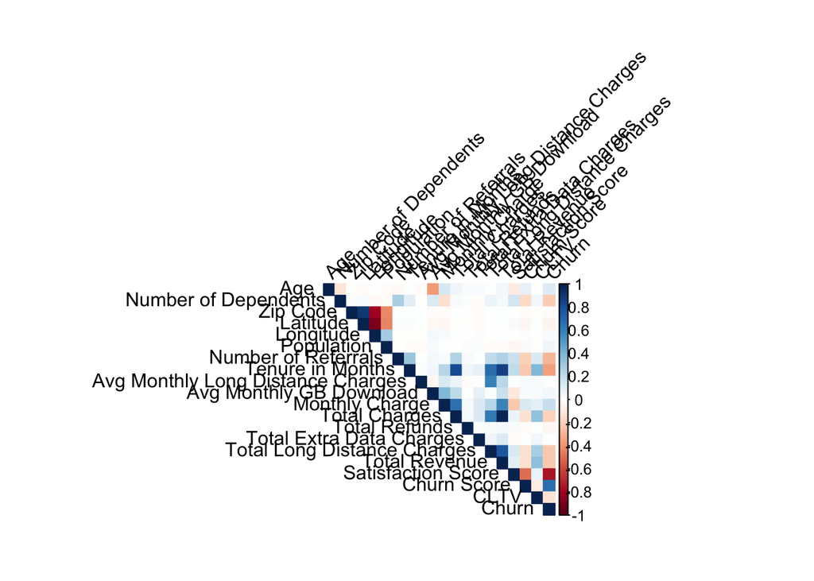

```r
#Correlation heatmap
library(corrplot)
cor_data <- telco_clean %>% select(where(is.numeric))
cor_matrix <- cor(cor_data)
corrplot(cor_matrix, method = "color", type = "upper", tl.col = "black", tl.srt = 45)
```

```r
# Goals:
# Analyze the distribution of churn.
# Identify trends in numerical variables like tenure, MonthlyCharges, etc.
# Visualize correlations between variables.
```

Focus on improving retention strategies for newer employees/customers. Evaluate pricing plans for high-paying customers to understand if they perceive value for money. Improve customer satisfaction by identifying pain points in services.

##Build a Predictive Model

```r
# Split data into train and test sets
library(caret)
set.seed(42)
train_index <- createDataPartition(telco_clean$Churn, p = 0.7, list = FALSE)
train <- telco_clean[train_index, ]
test <- telco_clean[-train_index, ]

# Train a logistic regression model
model <- glm(Churn ~ `Tenure in Months` + `Monthly Charge` + `Total Charges`, data = train, family = "binomial")

# Evaluate the model
summary(model)
```

```
##
## Call:
## glm(formula = Churn ~ `Tenure in Months` + `Monthly Charge` +
##     `Total Charges`, family = "binomial", data = train)
##
## Coefficients:
##                      Estimate Std. Error z value Pr(>|z|)
## (Intercept)        -1.7129771  0.1425789 -12.014   <2e-16 ***
## `Tenure in Months` -0.0639126  0.0063949  -9.994   <2e-16 ***
## `Monthly Charge`    0.0320052  0.0020851  15.350   <2e-16 ***
## `Total Charges`     0.0001129  0.0000722   1.564    0.118
## ---
## Signif. codes:  0 '***' 0.001 '**' 0.01 '*' 0.05 '.' 0.1 ' ' 1
##
## (Dispersion parameter for binomial family taken to be 1)
##
##     Null deviance: 5737.4  on 4930  degrees of freedom
## Residual deviance: 4475.2  on 4927  degrees of freedom
## AIC: 4483.2
##
## Number of Fisher Scoring iterations: 6
```

```r
pred <- predict(model, test, type = "response")
conf_matrix <- table(Predicted = ifelse(pred > 0.5, 1, 0), Actual = test$Churn)
conf_matrix
```

```
##          Actual
## Predicted    0    1
##         0 1407  306
##         1  160  239
```

```r
# Goals:
# Train a simple logistic regression model to predict churn.
# Identify the most important predictors of churn.
```

Observations: Significant predictors (p < 0.05): Tenure in Months (negative coefficient): Longer tenure reduces churn likelihood. Monthly Charge (positive coefficient): Higher charges increase churn likelihood. Non-significant predictor: Total Charges: Likely collinear with Tenure in Months. Insight: Focus on improving tenure and addressing high monthly charges to reduce churn.

## Data Vizualizations

#Bar Chart: Show churn rates by contract type

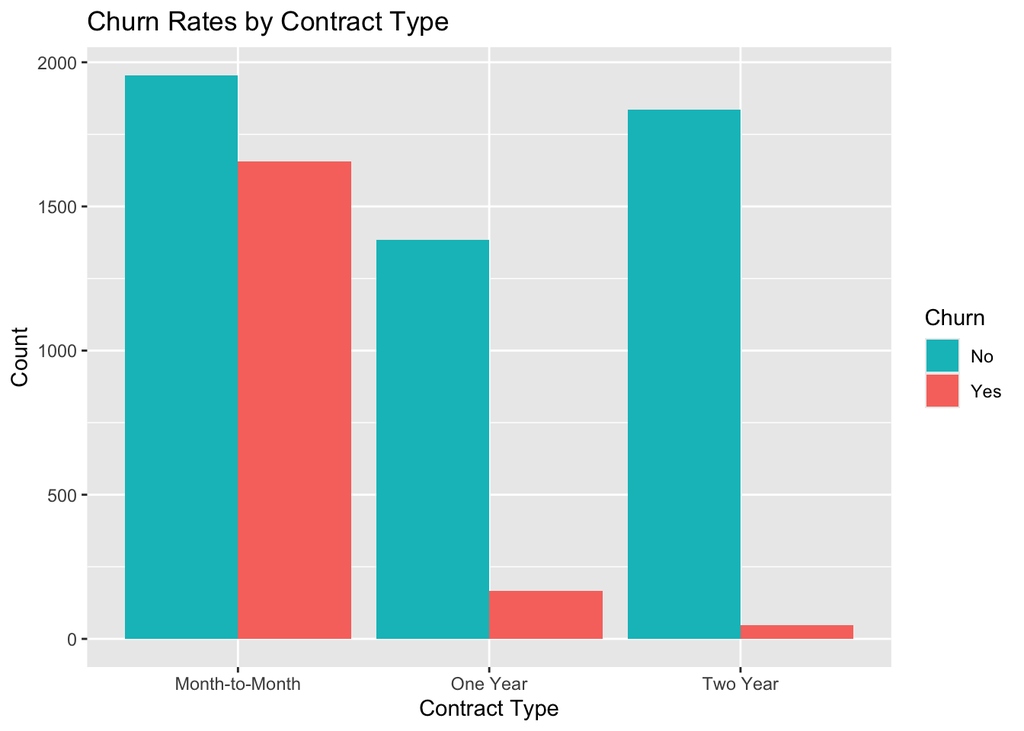

```r
#Bar Chart: Show churn rates by contract type
library(ggplot2)

# Bar chart of churn rates by contract type
ggplot(telco_clean, aes(x = Contract, fill = factor(Churn))) +
  geom_bar(position = "dodge") +
  labs(title = "Churn Rates by Contract Type", x = "Contract Type", y = "Count") +
  scale_fill_manual(values = c("#00BFC4", "#F8766D"), name = "Churn", labels = c("No", "Yes"))
```

Observations: Customers with month-to-month contracts churn the most. Churn rates are much lower for one-year and two-year contracts. Insight: Long-term contracts reduce churn, possibly due to commitment and incentives.

#Box Plot: Compare tenure between churned and non-churned customers.

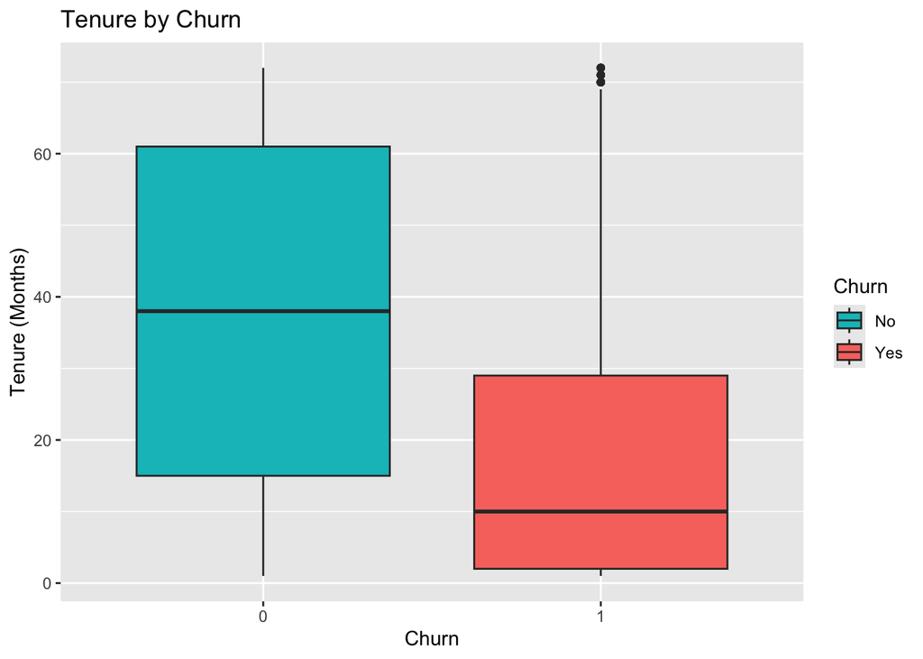

```r
# Box plot of tenure by churn
ggplot(telco_clean, aes(x = factor(Churn), y = `Tenure in Months`, fill = factor(Churn))) +
  geom_boxplot() +
  labs(title = "Tenure by Churn", x = "Churn", y = "Tenure (Months)") +
  scale_fill_manual(values = c("#00BFC4", "#F8766D"), name = "Churn", labels = c("No", "Yes"))
```

Observations: Non-churners (Churn = No) have significantly longer tenure, as indicated by the wider interquartile range and higher median. Churners (Churn = Yes) have shorter tenure overall. Insight: Shorter tenure is a strong indicator of churn, possibly due to dissatisfaction or lack of engagement early in the customer lifecycle.

#Heatmap: Correlation matrix for numerical variables.

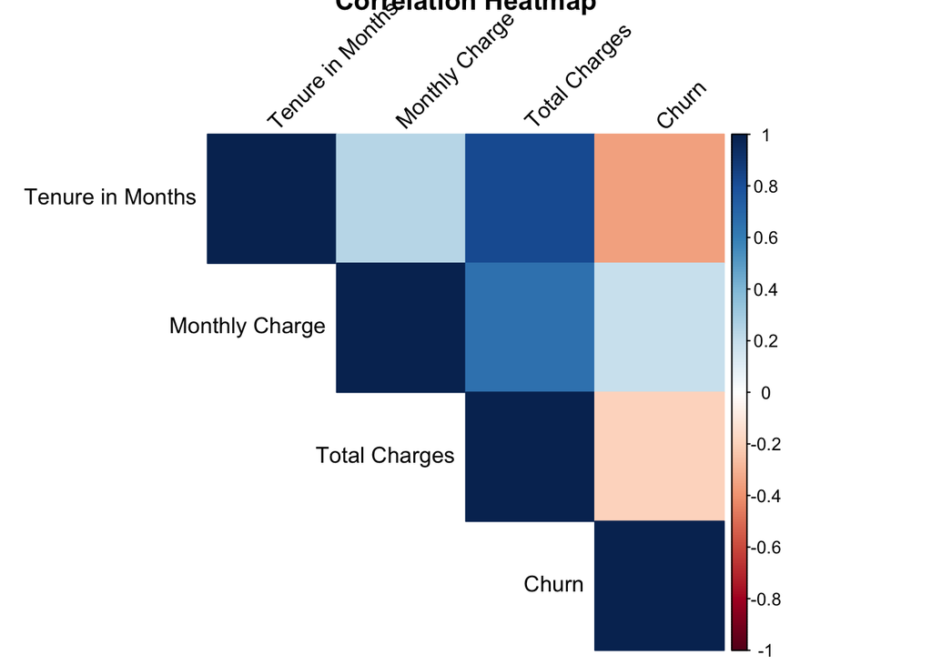

```r
library(corrplot)

# Calculate correlation matrix
num_data <- telco_clean %>% select(`Tenure in Months`, `Monthly Charge`, `Total Charges`, Churn)
cor_matrix <- cor(num_data)

# Create a heatmap
corrplot(cor_matrix, method = "color", type = "upper", tl.col = "black", tl.srt = 45,
         title = "Correlation Heatmap")
```

Observations: Tenure in Months is negatively correlated with churn, confirming the insights from the box plot. Monthly Charge has a slight positive correlation with churn. Total Charges has a weak correlation with churn, likely because it reflects tenure. Insight: Tenure is a key predictor, while Monthly Charge may influence churn when combined with other factors.

# Scatter plot of Monthly Charges vs. Total Charges

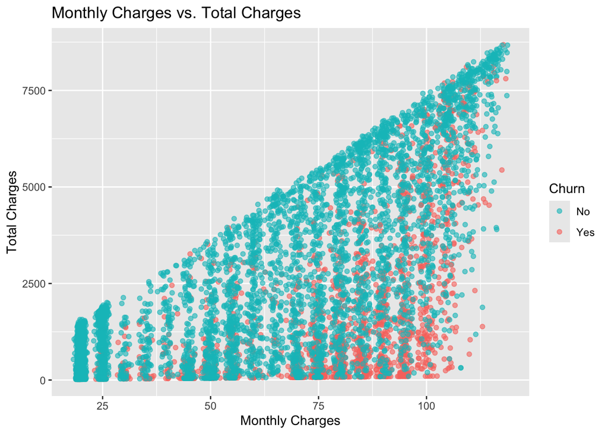

```r
#ScatterPlot
ggplot(telco_clean, aes(x = `Monthly Charge`, y = `Total Charges`, color = factor(Churn))) +
  geom_point(alpha = 0.6) +
  labs(title = "Monthly Charges vs. Total Charges", x = "Monthly Charges", y = "Total Charges") +
  scale_color_manual(values = c("#00BFC4", "#F8766D"), name = "Churn", labels = c("No", "Yes"))
```

Observations: A linear trend is visible between Monthly Charge and Total Charges for non-churners and churners. Churners are distributed across all ranges of monthly charges but seem more concentrated in lower total charges. Insight: Customers with lower cumulative charges (shorter tenure) tend to churn more.

# Histogram of Monthly Charges

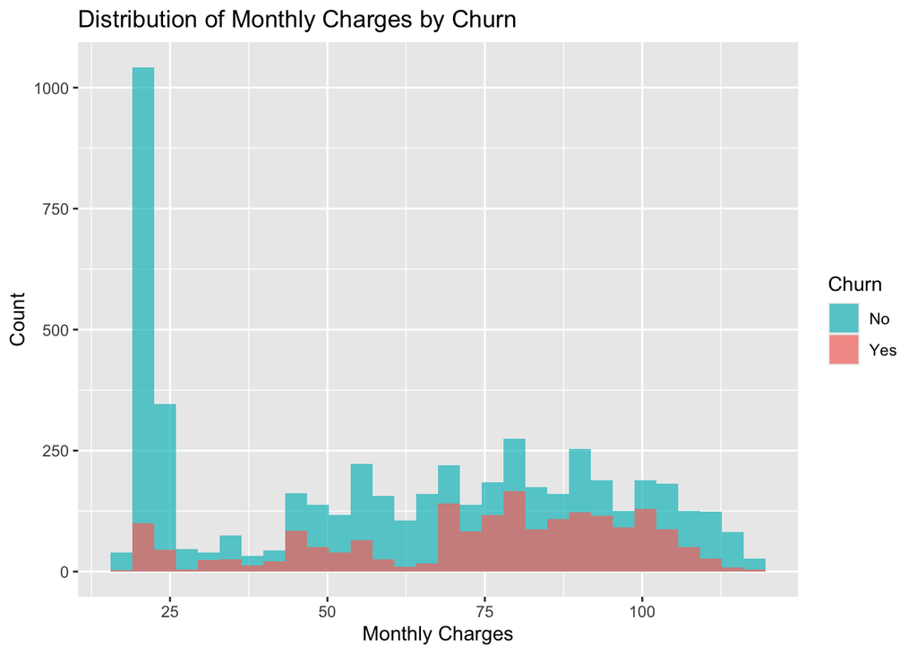

```r
# Histogram
ggplot(telco_clean, aes(x = `Monthly Charge`, fill = factor(Churn))) +
  geom_histogram(bins = 30, alpha = 0.7, position = "identity") +
  labs(title = "Distribution of Monthly Charges by Churn", x = "Monthly Charges", y = "Count") +
  scale_fill_manual(values = c("#00BFC4", "#F8766D"), name = "Churn", labels = c("No", "Yes"))
```

Objective: The histogram compares the distribution of monthly charges for churned (Yes) vs. non-churned (No) customers. Insights: Customers with lower monthly charges (around $20–$40) tend to churn less frequently. A higher proportion of churned customers are observed in the $70–$100 range. The distribution suggests that higher charges may be a significant factor in customer attrition. Actionable Steps: Offer customized retention plans for high-paying customers. Consider offering discounts or value-added services to customers in the higher charge brackets. Investigate if the features/services offered at higher price points meet customer expectations.